# Airline on-time performance

> **Report date : February, 2023**  
> **Written by : [Ekoue LOGOSU-TEKO](https://www.linkedin.com/in/ekouelogosuteko/?locale=en_US)**

## Investigation Overview

In this investigation, I wanted to analyse planes on-time performance. More specifically, I wanted to understand which factors are involved in a plane departure delay, the main focus of the investigation, from an airport. The investigation showed that departure delay and arrival delay have a high a positive correlation, which mean an increase on departure delay cause an increase in arrival delay, which is why arrival delay correlation with other variables wasn't a target of in-depth investigation.

## Dataset Overview

The data reports flights in the US, including carriers, arrival and departure delays, and reasons for delays from 2005 to 2008. It total weight is 2.12 Gb.  
It is downloaded from [here](https://dataverse.harvard.edu/dataset.xhtml?persistentId=doi:10.7910/DVN/HG7NV7)  
Its features can be consulted [here](https://www.transtats.bts.gov/DatabaseInfo.asp?QO_VQ=EFD&Yv0x=D) After data wrangling, the are 17014015 flights and 41 features left. Those flights data were saved in to allow them to be used in this explanatory notebook.

## Exploring departure delay and arrival delay distribution

Departure delay and Arrival delay have a high positive correlation because of the ripple effect. 75% of planes have a departure delay of 11 minutes, while for 75% of planes the arrival delay is 15 minutes. Plotted on a logarithmic scale, the distribution of depature and arrival delays is skewed toward the right, with many spikes on the first half of the plots. Those spikes should suggest the usual delay of the majority of planes.  
For the follow up of the analysis, the focus will be on departure delay, since we already know by its correlation with arrival delay that they two will increase together.

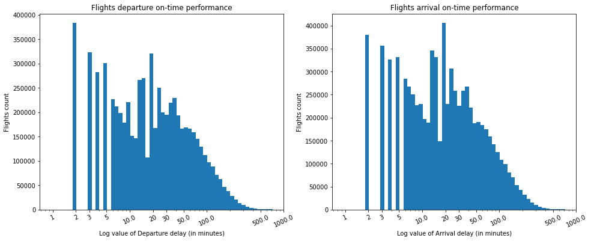

## Carriers involvement in departure delay

For one reason or another, each freight company planes tend to perform differently than others in term of departure delay. For example, some companies planes usually depart before or less than 05 minutes after the scheduled time, some companies planes tend to depart 15 to 17 minutes after the scheduled time, whereas there are companies' planes which tend to depart around 10 minutes after the scheduled time. It is worth to ponder why.

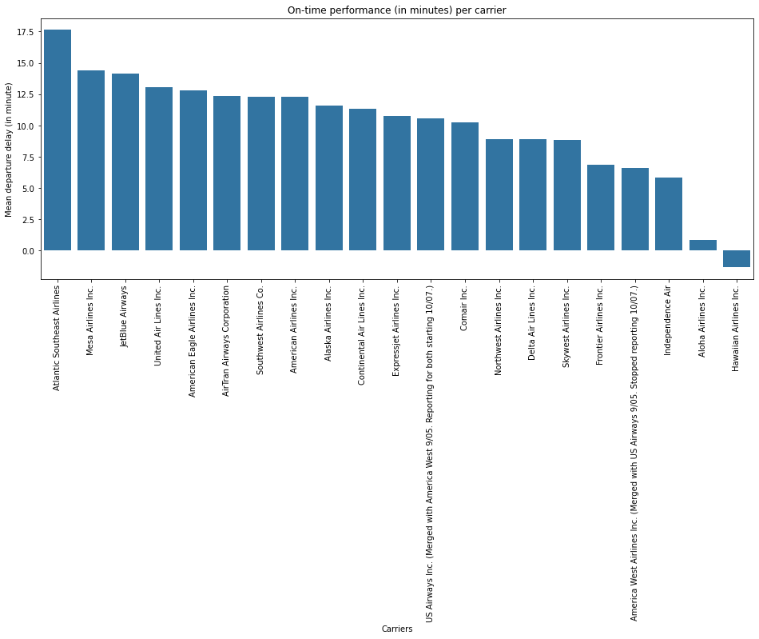

## Cities involvement in the departure delay of planes

I found during my investigation that the departure delay is nearly similar for many cities, while there are cities whose departure delay are either better or worst than than the others. From this, I can conclude that the city play a role in planes on-time performance.

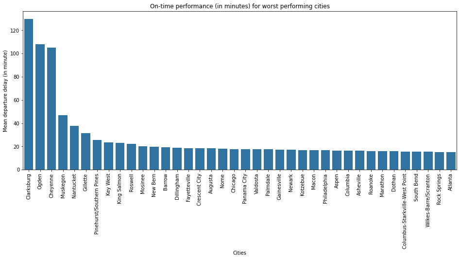

On this second plot, we have cities where planes usual departure delay span from 03 minutes before the scheduled time to 05 minutes after the scheduled time.

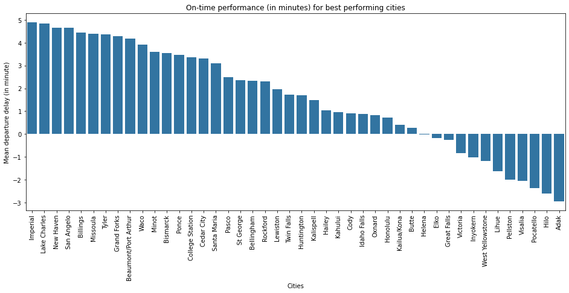

## Weekday's impact on planes on-time performance

Planes tend to be more delayed Thursday and Friday, with a mean departure delay between 12 to nearly 14 minutes. The weekdays where to expect the less departure delay is Tuesday and Saturday, where the mean departure delay is around 09 minutes. For the other days, it is to be expected a mean depature delay of about 10 to lesser than 12 minutes.

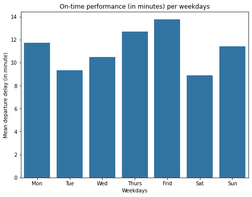

## Month's impact on planes on-time performance

The analysis shows that months are also a factor impacting planes' departure delay.  
May, September, October and November are the months with the less mean depature delay, ranging from 06 to 08 minutes. April and August are the next best ones, with a mean departure delay between 10 to 12 minutes. The other months have a slight higher departure delay.

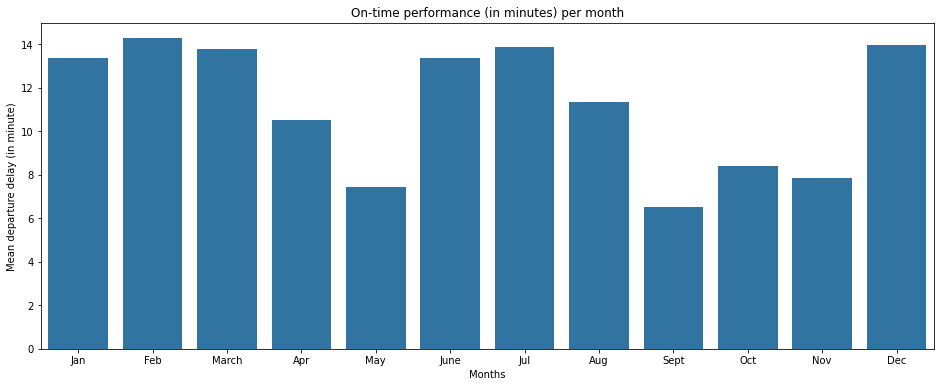